# Predicting how tightly a drug binds its target

Benchmarking Savant against PRODIGY-LIG and Boltz-2

Author

Sayal Guirales-Medrano

Published

August 20, 2026

## The short version

We tested three tools, and then a fourth we built, on the same 1,000 protein–drug pairs where the true binding strength is known from experiments.

- **Savant v1**, our original tool, performed about the same as **PRODIGY-LIG**, a much simpler and much faster method. That was disappointing: v1 needed hours of computation per pair to match something that takes seconds.
- We found out why, rebuilt the tool as **Savant v2**, and it now clearly beats both v1 and PRODIGY-LIG — while running about a hundred times faster than v1.
- **Boltz-2**, a large AI model that needs a graphics card, is still the most accurate. Savant v2 closes part of the gap and runs on an ordinary laptop.

## 0.1 What we are trying to predict

When a drug binds a protein, we describe the strength of that binding with a number called **Kd**, measured in nanomolar (nM).

**Kd is the drug concentration at which half of the protein is occupied.** So a *lower* Kd means a *stronger* drug — less of it is needed to do the job.

- Kd of 1 nM → very strong binding, typical of a good drug
- Kd of 1,000 nM → moderate
- Kd of 1,000,000 nM → very weak, essentially useless

Kd values cover an enormous range. In our test set the real values run from 0.002 nM to 6,810,000 nM — a factor of over a billion. That is why every chart here uses a **logarithmic scale**, where each step is a ten-fold change rather than a fixed amount.

It also changes how we measure error. Being “500 nM off” means nothing on its own: it is a catastrophic miss for a 1 nM drug and a rounding error for a 1,000,000 nM one. So we ask instead: **how many times off was the prediction?** A prediction of 100 nM when the truth is 10 nM is “10-fold off”. Getting within 10-fold is the practical standard for a useful prediction.

## 0.2 The test set

```
1000 protein-drug pairs across 355 different proteins
True Kd ranges from 0.002 nM to 6.81e+06 nM
Median true Kd: 448 nM
```

Two rules make this a genuinely hard test rather than a flattering one:

1. **No drug in the test set closely resembles anything Savant was trained on.** Chemically similar molecules were removed, so the tool cannot succeed by recognising something it has seen before.
2. **The proteins are labelled by how familiar they are** — some appear in training, some are relatives, and some are from protein families the tool has never encountered.

Every tool was given the same 3D structures of each protein–drug pair, predicted by Boltz-2, so no tool has an advantage from a better starting structure.

# 1 Round one: how Savant v1 did

## 1.1 The picture

Each dot below is one protein–drug pair. The horizontal position is the **true** Kd from the experiment; the vertical position is what the tool **predicted**.

The diagonal line is a perfect prediction. Dots on the line are exactly right. Dots above the line mean the tool predicted weaker binding than reality; below the line means it predicted stronger. The shaded band shows the region within 10-fold of the truth.

**What to look for:** a tool that is working shows dots forming a diagonal stripe. A tool that is not shows a flat horizontal cloud — it is guessing about the same answer regardless of the drug.

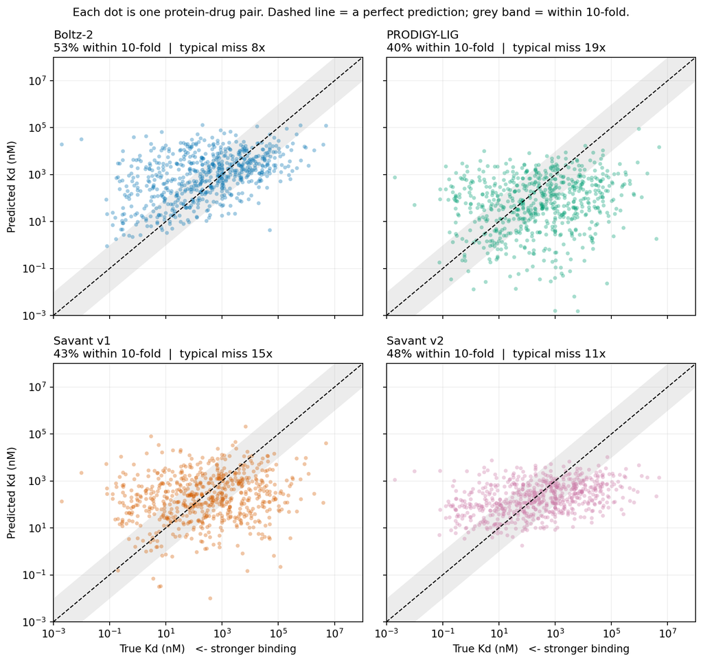

Figure 1: Predicted versus true binding strength for all four tools. Both axes are Kd in nanomolar on a log scale, so each gridline is a ten-fold change. Strong binders sit toward the lower left of each panel.

The difference is visible without any statistics. Boltz-2’s cloud tilts along the diagonal. Savant v1’s and PRODIGY-LIG’s clouds are much flatter — they spread up and down almost regardless of the true value, which is what a weak predictor looks like.

## 1.2 The numbers

Table 1

| Tool | Pairs scored | Typical error (fold) | Within 10-fold (%) | Within 100-fold (%) | Correlation |
| --- | --- | --- | --- | --- | --- |
| Boltz-2 | 647 | 8x | 53% | 80% | 0.45 |
| PRODIGY-LIG | 647 | 19x | 40% | 68% | 0.17 |
| Savant v1 | 647 | 15x | 43% | 72% | 0.16 |

Reading the table:

- **Typical error (fold)** — the middle prediction was off by this many times. Smaller is better.
- **Within 10-fold** — the share of predictions close enough to be useful. Bigger is better.
- **Correlation** — whether the tool ranks drugs correctly, from 0 (no relationship) to 1 (perfect). This matters most in practice, because the usual question is “which of these drugs is best?”, not “what is the exact number?”

## 1.3 What this told us

**Savant v1 was no better than PRODIGY-LIG.** Its correlation of 0.16 sits essentially level with PRODIGY-LIG’s 0.17, and a statistical test comparing them on identical pairs found no reliable difference between the two.

That is a problem, because the two tools are not remotely comparable in cost:

|  | Savant v1 | PRODIGY-LIG |
| --- | --- | --- |
| What it needs | AlphaFold3 structure + HADDOCK energy simulation | just the structure |
| Time per pair | minutes to hours | about a second |
| Hardware | computing cluster | any laptop |
| Result | correlation 0.16 | correlation 0.17 |

Savant v1 also **refused to answer for 353 of the 1,000 pairs**. It has a first step that decides whether a drug binds at all, and only predicts a strength for those that pass. That filter rejected a third of the pairs — every one of which was a real, experimentally confirmed binder.

So v1 was doing far more work than PRODIGY-LIG, answering fewer questions, and arriving at the same accuracy.

# 2 What we changed, and why

## 2.1 Finding out where the effort was going

Savant v1 described each protein–drug pair with 18 numbers. Eleven described the drug alone. The other seven came from HADDOCK, a physics simulation that estimates the energy of the interaction — and that was the slow, expensive part of the whole pipeline.

We tested how much each group of numbers actually contributed by retraining the model with different combinations:

| What the model was given | Correlation |
| --- | --- |
| The drug only — no protein, no structure at all | 0.25 |
| Drug + a simple count of how many contacts it makes | 0.26 |
| Drug + all seven HADDOCK energy numbers | 0.27 |

**The seven HADDOCK numbers were worth 0.01.** A simple count of atomic contacts, which takes milliseconds, did nearly the same job as hours of physics simulation.

Worse, a model given *only* the drug’s chemical properties — never seeing the protein or the 3D structure — scored 0.25. Almost everything v1 achieved could be achieved without looking at the protein at all.

The reason became clear when we examined the training data: **it contained no information identifying the protein.** Just the drug’s properties and those seven energy numbers. Two completely different proteins with similar contact energies looked identical to the model. It never had a chance to learn which protein it was dealing with.

## 2.2 The two changes we made

**1. We removed HADDOCK and described the interaction directly instead.**

Rather than compressing a whole interface into seven energy values, Savant v2 counts what is physically there:

- hydrophobic contacts (greasy parts touching greasy parts)
- hydrogen bonds
- salt bridges (opposite charges attracting)
- ring stacking, split by whether the rings are face-to-face or edge-on
- halogen bonds and metal contacts
- how much of the drug’s surface is buried inside the pocket
- which **kinds of amino acid** line the pocket — this is how the protein finally enters the picture

This is roughly 650 numbers instead of 18, all computed from geometry in about one second on a single processor core. No physics simulation, no cluster.

**2. We retrained both models properly.**

Savant keeps the same two-step design as v1 — one model decides *does this bind at all?*, a second predicts *how strongly?* — but both were rebuilt:

We also switched the underlying algorithm from XGBoost to scikit-learn’s gradient boosting. We checked this made no difference to accuracy (correlation 0.446 versus 0.453 on the same data); it simply removes a dependency.

# 3 Round two: how Savant v2 did

Table 2

| Tool | Pairs scored | Typical error (fold) | Within 10-fold (%) | Within 100-fold (%) | Correlation |
| --- | --- | --- | --- | --- | --- |
| Boltz-2 | 647 | 8x | 53% | 80% | 0.45 |
| Savant v2 | 647 | 11x | 48% | 82% | 0.37 |
| Savant v1 | 647 | 15x | 43% | 72% | 0.16 |
| PRODIGY-LIG | 647 | 19x | 40% | 68% | 0.17 |

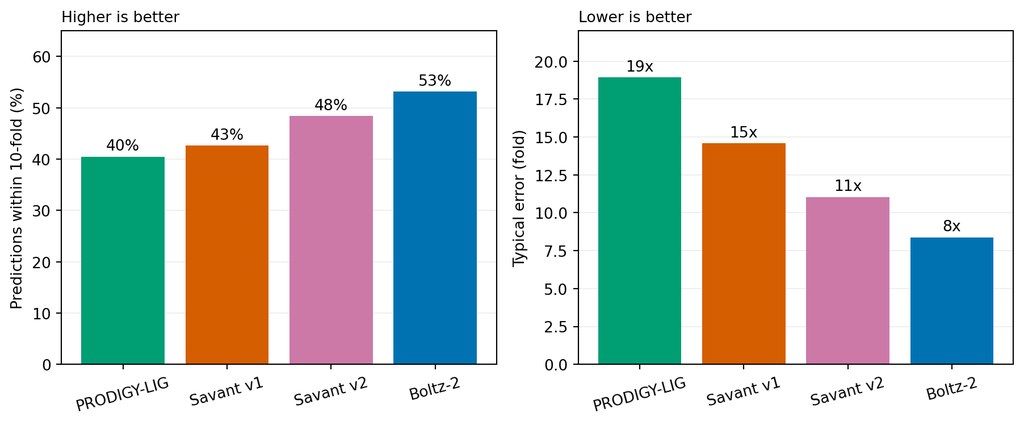

Figure 2: How often each tool lands within 10-fold of the true binding strength, and how far off the typical prediction is.

## 3.1 What improved

**Against Savant v1**, on exactly the same pairs:

- correlation more than doubled, 0.16 → 0.37
- the typical prediction went from 15-fold off to 11-fold off
- it now answers for **960 pairs instead of 647**

And it does this while being *faster* than v1, not slower: about one second per pair on a laptop, versus minutes on a cluster.

**Against Boltz-2**, Savant v2 is still behind on correlation (0.37 versus 0.45). Boltz-2 remains the most accurate tool we tested. It also needs a graphics card, takes minutes per pair, and gives a single number with no explanation.

## 3.2 What Savant v2 gives that the others do not

For each prediction, it reports the interactions it found — how many hydrogen bonds, which amino acids the drug touches, how deeply buried it is. For example, on a real fatty-acid binding protein:

```
prediction   BINDER  (probability 1.00)
affinity     Kd 71 nM
interface    18 residues, 851 A^2 buried, ligand 99% enclosed
interactions
  hydrophobic contacts            134
  hydrogen bonds                    4
  salt bridges                      6
contacting residues  TYR x4, ILE x3, VAL x3, PHE x1, LYS x1
```

That description matches the known chemistry — a greasy molecule packed into a greasy pocket with its acid end anchored by charged contacts. Neither Boltz-2 nor PRODIGY-LIG produces anything like it.

# 4 Full performance metrics

The tables above used fold-error because it is the easiest number to picture. This section gives the five standard metrics as well, so these results can be compared against published work.

## 4.1 How to read them

All five are calculated on the **log scale** (pKd), not on Kd directly. That is deliberate. On the Kd scale, a handful of very weak binders with true values in the millions of nM would dominate every average and drown out what the tool does on everything else. On the log scale each whole unit is a ten-fold change, which keeps every pair contributing equally.

The useful translation:

| Metric | What it measures | Rough meaning | Better |
| --- | --- | --- | --- |
| **RMSE** | typical error, punishing big misses extra | 1.0 ≈ 10-fold out | lower |
| **MAE** | typical error, treating all misses equally | 1.0 ≈ 10-fold out | lower |
| **MAPE** | average error as a % of the true value | 20% ≈ a fifth off | lower |
| **Pearson r** | does the prediction rise and fall with the truth? | 0 = none, 1 = perfect | higher |
| **Spearman ρ** | does it put the drugs in the right order? | 0 = none, 1 = perfect | higher |

RMSE and MAE answer *how far off*. Pearson and Spearman answer *does it rank correctly* — usually the more important question, since the practical use is choosing the best drug from a list rather than predicting an exact number.

Comparing RMSE and MAE is informative in itself: RMSE is always the larger of the two, and the bigger the gap between them, the more a tool’s error is driven by a few very large misses rather than by being consistently a little off.

## 4.2 The comparison set

Table 3: All five metrics on the 647 pairs that every tool scored. Sorted by Pearson correlation.

| Tool | Pairs | RMSE | MAE | MAPE (%) | Pearson r | Spearman rho |
| --- | --- | --- | --- | --- | --- | --- |
| Boltz-2 | 647 | 1.55 | 1.19 | 18.2 | 0.451 | 0.430 |
| Savant v2 | 647 | 1.50 | 1.21 | 20.7 | 0.367 | 0.377 |
| PRODIGY-LIG (+elec) | 647 | 1.93 | 1.51 | 26.1 | 0.195 | 0.211 |
| PRODIGY-LIG | 647 | 1.99 | 1.58 | 27.5 | 0.167 | 0.178 |
| Savant v1 | 647 | 1.77 | 1.41 | 23.9 | 0.156 | 0.159 |

This uses only the pairs **all five tools managed to score**, so no tool is helped or hurt by having answered an easier or harder subset. Savant v1 is what limits this to 647 of the 1,000 pairs.

Two things stand out.

**Savant v2 has the lowest RMSE of any tool, including Boltz-2** (1.50 versus 1.55), while Boltz-2 leads clearly on both correlations. So v2’s individual predictions are, on average, marginally closer to the truth — but Boltz-2 is better at telling strong binders from weak ones.

**Savant v1 ranks third on error but last on correlation.** Its RMSE (1.77) beats both PRODIGY-LIG variants, yet its Pearson r (0.156) is the worst in the table. That looks contradictory, and the reason is a trap worth knowing about:

> A model can score well on RMSE by predicting close to the dataset average every time. Most true values sit near the middle, so playing it safe is rarely badly wrong — even if the prediction barely changes from one drug to the next.

You can see exactly how much each tool plays it safe by comparing how spread out its predictions are against how spread out the real values are:

Table 4

| Tool | Spread of values | As % of the truth |
| --- | --- | --- |
| The true values | 1.61 | 100% |
| Boltz-2 | 1.00 | 62% |
| PRODIGY-LIG | 1.25 | 78% |
| Savant v1 | 1.03 | 64% |
| Savant v2 | 0.69 | 43% |
| PRODIGY-LIG (+elec) | 1.28 | 80% |

Every tool hedges — none of them spread their answers as widely as reality does. Savant v1 covers 64% of the true spread against PRODIGY-LIG’s 78%, so v1 is the more cautious of the two, and that caution is what buys it the better RMSE.

But notice that **Savant v2 hedges the most of all** (43%) and still has both the best RMSE *and* the second-best correlation. So playing it safe is not by itself what ruins a tool. Being cautious lowers your error; whether your answers still line up in the right order is a separate question, and that is what correlation measures.

**This is why correlation is the metric to trust here.** RMSE cannot tell apart a tool that is genuinely tracking the truth from one that is quietly guessing the average — and Savant v1 versus PRODIGY-LIG is exactly that situation. If you are choosing which compound to test next, ranking is the whole job.

## 4.3 Each tool on everything it scored

Table 5: Each tool measured on every pair it produced an answer for. Coverage differs, so these rows are not strictly like-for-like.

| Tool | Pairs | RMSE | MAE | MAPE (%) | Pearson r | Spearman rho |
| --- | --- | --- | --- | --- | --- | --- |
| Boltz-2 | 960 | 1.59 | 1.24 | 20.1 | 0.471 | 0.444 |
| Savant v2 | 960 | 1.64 | 1.32 | 23.9 | 0.327 | 0.315 |
| PRODIGY-LIG | 960 | 2.14 | 1.70 | 30.0 | 0.197 | 0.205 |
| PRODIGY-LIG (+elec) | 935 | 2.29 | 1.70 | 29.8 | 0.189 | 0.204 |
| Savant v1 | 647 | 1.77 | 1.41 | 23.9 | 0.156 | 0.159 |

This second table is the more realistic view of day-to-day use, because it includes every answer each tool actually gave. But the row counts differ, so it should not be used for a head-to-head claim — Savant v1’s 647 pairs are the subset its own filter accepted, which is not a random sample of the benchmark.

Both views agree on the conclusion: Boltz-2 first, Savant v2 second, then a clear gap to PRODIGY-LIG and Savant v1.

# 5 Honest limitations

**Boltz-2 is still more accurate.** We narrowed the gap; we did not close it.

**Savant v2 is much better on familiar proteins than unfamiliar ones.**

Table 6

| How familiar is the protein? | Pairs | Boltz-2 | Savant v2 | PRODIGY-LIG |
| --- | --- | --- | --- | --- |
| Protein seen in training | 382 | 0.56 | 0.45 | 0.21 |
| Related protein seen | 399 | 0.40 | 0.25 | 0.16 |
| Protein family never seen | 179 | 0.34 | 0.11 | 0.20 |

On proteins it has seen, Savant v2 (0.45) approaches Boltz-2 (0.56). On protein families it has never encountered, it drops to 0.11 — below PRODIGY-LIG’s 0.20. PRODIGY-LIG is built on physics, which works the same everywhere; Savant learns patterns from data, and unfamiliar biology is where learned patterns fail.

**The uncertainty ranges are too narrow on unfamiliar proteins.** They are built to be right 90% of the time, and on this test set they were right 64% of the time. The ranges are honest on data resembling the training set and overconfident beyond it.

**40 of the 1,000 pairs are missing** because the structure-prediction step never produced a structure for them, mostly very large drug molecules. That is a gap in the input, not in the scoring.

# 6 What this means

Savant v1 did a large amount of expensive work to match a tool that runs in a second. Finding that out required building the benchmark and testing honestly.

Savant v2 turned that into a real improvement by spending the effort in a different place — describing what the drug and protein are actually doing to each other, rather than compressing it into a handful of energy numbers — and by letting the model see which protein it is looking at.

The result is a tool that runs on a laptop in about a second, clearly beats the fast alternative, reports how confident it is, and explains its reasoning. It is not the most accurate option available; Boltz-2 is. It is the most accurate option that a biologist can run on their own computer, on a structure they already have.